# 中国女排教练新手指南

## ——女排国际竞争力现况及国内选才建队思路分析

## 准备工作

```r
library(readxl)
library(RColorBrewer)
library(ggplot2)
library(apyramid)
library(apyramid)
library(data.table)
```

## 1. 背景介绍

随着一批功勋冠军球员的退役，中国女排已经几乎告别了里约周期的黄金一代。如今的巴黎周期可谓风雨飘摇，球队经历了换帅、人才短缺、队员伤病等等令球迷揪心的问题。而距离巴黎奥运会仅剩不到半年，中国女排仍未确定拿到奥运会入场券，球队参赛名单也扑朔迷离，世界排名已然掉出以前稳定的前三，可其他国家队已经新人辈出、老将成熟……此时可谓中国女排的危急时刻。因此，本报告希望读者以女排主教练的视角，借助数据分析考察国际女排的现状、发展趋势和中国女排的现有世界地位，并了解优秀的国际排球运动员需要具备的基本品质，从而搭建出初步的选拔人才、建设队伍的策略。

## 2. 数据来源与说明

本报告使用世界女排球员数据和国家队世界排名及积分进行数据分析。女排球员数据从数据库共享平台[Kaggle](https://www.kaggle.com/datasets/ekrembayar/volleyball-women-players-database-volleybox?resource=download)上下载，该数据库爬取自海外主流排球数据网站[Volleybox](https://women.volleybox.net/players) ，包含78694名现役或已退役的国际球员的各类信息，例如姓名、出生日期、国籍、身高、扣高、惯用手、所在俱乐部、历史参赛场次、历史排名、2023年世界排名等。数据由Volleybox运营人员进行及时上传更新，也可由球员本人进行注册并添加，具有较高的时效性与可靠性，但由于数据集囊括各等级联赛的已注册球员，既有效力于顶尖俱乐部的职业球员，也有效力于低等级职业联赛或大学生联赛的半职业球员或大众球员，故较多数据无法代表国际水平，需要在后续数据分析中进行筛选。 国家队世界排名及积分收集自[国际排联官网](https://en.volleyballworld.com/volleyball/world-ranking/women) ，选取2020年排名计算规则改革后、东京奥运会后和最新一期这三个时间节点的数据，确保计分规则相同以纵向比较单个国家的积分变化，同时保证时间节点的关键性使得世界排名信息更具分析和参考意义。报告选取12个国家的数据以对标奥运会决赛圈的参赛球队数量（并附上被禁赛的俄罗斯的数据）。 首先对球员数据进行初步观测与处理：表格中缺失数据均用NA表示，没有无效球员（即毫无信息）；使用Excel DATEDIF函数根据生日计算球员年龄，并使用数据分列对双国籍或多国籍进行处理，认为该球员同时属于这两个或多个国家或地区。

## 3. 数据的可视化描述

### 3.1 中国国家队在国际排坛的地位与竞争力

首先对中国女排过去4年（即奥运周期长度）的世界排名变化进行考察。选取计分规则改革后的三个时间点和12+1支国家队进行分析（因为奥运会决赛圈参赛队伍为12支，加上实力较强但由于禁药风波被国际奥委会在国际赛场上全面禁赛的俄罗斯队），绘制簇状条形图（图1）。簇状条形图横坐标为截止到该节点的积分，纵坐标为国家，按照最新的世界排名从高到低进行排序。

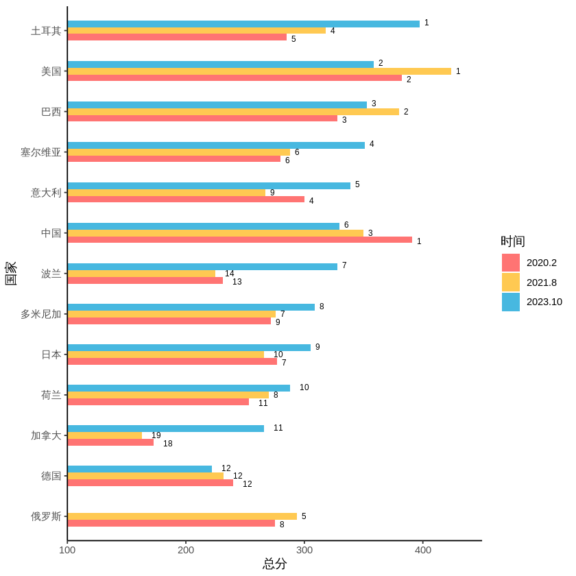

```r
#导入各国女排在2020.2, 2021.8和2023.10三个时间段的总积分和世界排名
country_ranking <- read_excel("score.xlsx")
#设置横坐标为积分(起点为100分)，纵坐标为国家，按照最新的世界排名从高到低进行排序
p1<-ggplot(country_ranking, aes(x = 总分-100, y = reorder(国家,-位次), fill = 时间)) +
  geom_bar(stat = "identity", position = "dodge",width=0.5) +
  scale_fill_manual(values = c("#ff7473", "#ffc952","#47b8e0")) +
  scale_x_continuous(expand = c(0, 0),limits = c(0,350), breaks = seq(0, 350, 100), labels = seq(100, 450, 100)) +
  theme_classic() +
  theme(plot.background = element_rect(fill = "white")) +
  geom_text(aes(label = 世界排名), position = position_dodge(width = 0.6),size = 2.5,hjust=-1)+
  labs(x="总分",y="国家")
  p1
```

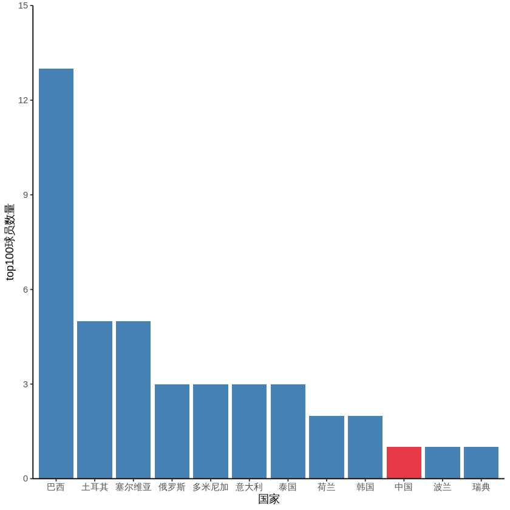

```r
#读取各国顶尖现役球员数量的数据文件
top_num<- readxl::read_xlsx("topnumber.xlsx")
p2<-ggplot(top_num,aes(x=reorder(国家,-top100球员数量),y=top100球员数量))+
  geom_bar(stat="identity",
  #突出中国的柱子为红色
  fill=c(rep("steelblue", nrow(top_num)-3),"#e63946",rep("steelblue",2)))+
  theme_classic()+
  theme(plot.background = element_rect(fill = "white"))+
  scale_y_continuous(expand = c(0, 0),breaks = seq(0, 15, 3),limits = c(0,15))+
  labs(x="国家")
p2
```

### 3.2 人才选拔标准

在对世界排坛现状有了基本认识后便可以着手分析国内高水平排球人才的个人能力。能力可以分为技术和身体素质，衡量技术水平需要观察并分析球员的实战表现，从而做出判断，但身体素质作为绝对能力可以通过数据分析进行衡量。因此报告基于全世界球员的海量数据，考察球员的具体竞技信息或能力，如扣高、惯用手等，分析高水平排球运动员需要具备的素质。 指导国家队选材需要在国际层面上横向对比水平相仿的球员，因此需要筛选出在高水平联赛打球且稳定出场的成熟活跃球员，因此数据选取2023年有世界排名且联赛出场大于5次的18岁以上现役球员的数据对身体素质进行分析。 排球运动中按照分工可分为五种球员，主攻、副攻、接应、二传和自由人，其在比赛中的职责各不相同，因此对身高、扣球高度、惯用手等能力的要求不同，球员或者教练会参考球员的特征决定球员在职业比赛中的角色。这些数据能指导教练对特定位置进行人才培养或人才储备。报告将基于球员的不同职责分析各位置最关键的身体条件。 值得注意的是，球员分类中还包含全能型球员，他们没有固定的角色。在已退役球员中，全能型选手占所有选手的6.52%，而在现役球员中全能型选手占所有选手的4.38%，表明现役的全能型球员比例逐渐下降，现在排球比赛更高的强度需要选手各司其职高效训练，因此在以后的分析中剔除全能型球员的数据。

#### 3.2.1 身高

排球女网网高为2.24米，对于有进攻和拦网任务的球员来说身高是非常关键的硬性指标，而对于自由人这类球员则没有严格的身高要求。使用箱线图考察不同位置球员的身高分布，如图3所示。

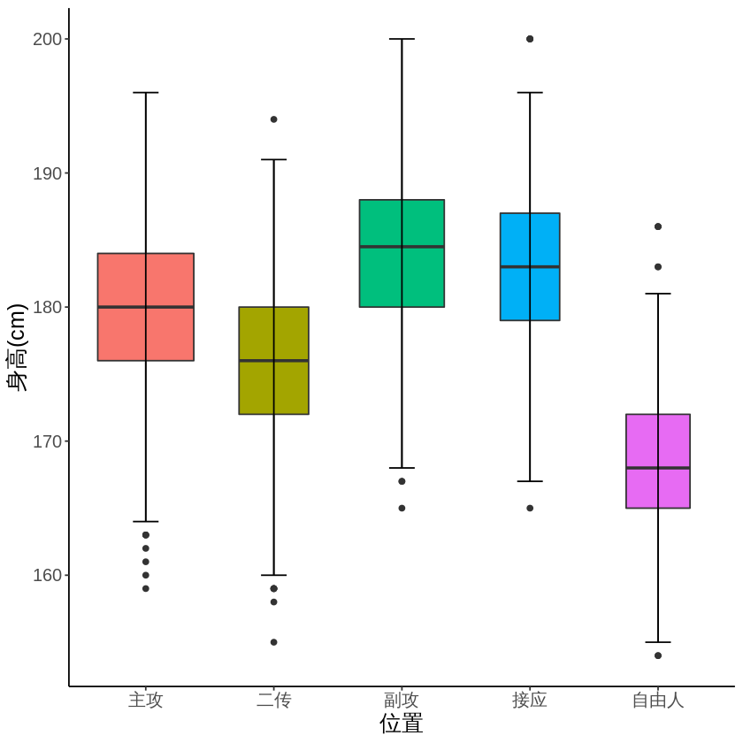

```r
#导入球员数据主数据文件，读取第一个表单
pos_height<- readxl::read_xlsx("main_data.xlsx")
#设置变量类型
pos_height$位置<-as.factor(pos_height$位置)
pos_height$身高<-as.numeric(pos_height$身高)
#绘制箱线图，设置误差线
p3<-ggplot(pos_height, aes(x=位置, y=身高)) +
  geom_boxplot(aes(fill = 位置),varwidth = TRUE,show.legend = F)+
  stat_boxplot(geom = "errorbar",
               lwd=0.5,
               width=0.2)+
  xlab("位置") +
  ylab("身高(cm)")+
  theme_classic()+
  theme(plot.background = element_rect(fill = "white"),text=element_text(size=15))
p3
```

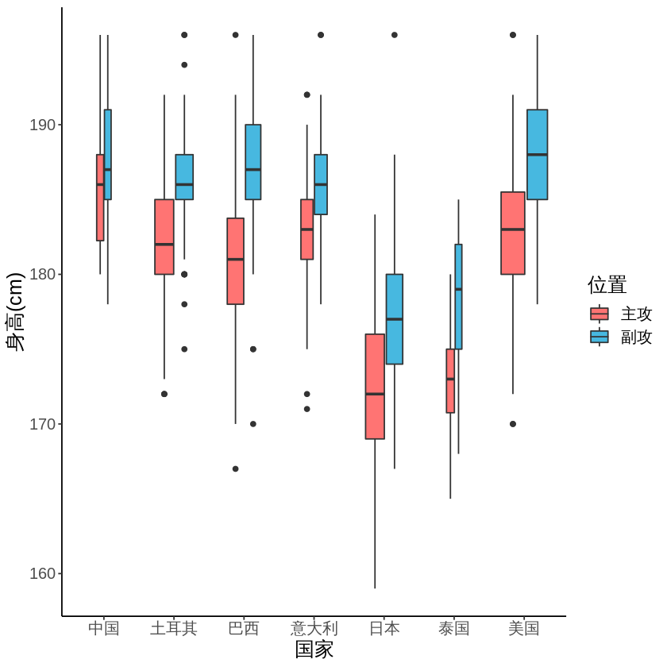

```r
#读取数据
coun_height<- readxl::read_xlsx("main_data.xlsx",sheet=2)
#设置变量类型
coun_height$位置<-as.factor(coun_height$位置)
coun_height$国家<-as.factor(coun_height$国家)
coun_height$身高<-as.numeric(coun_height$身高)
#绘制分组箱线图，自定义颜色
p4<-ggplot(coun_height, aes(x=国家, y=身高,fill = 位置)) +
  geom_boxplot(varwidth = TRUE,show.legend = T)+
  scale_fill_manual(values=c("#ff7473","#47b8e0"))+
  xlab("国家") +
  ylab("身高(cm)")+
  theme_classic()+
  theme(text=element_text(size=15))+
  theme(plot.background = element_rect(fill = "white"))
p4
```

#### 3.2.2 惯用手

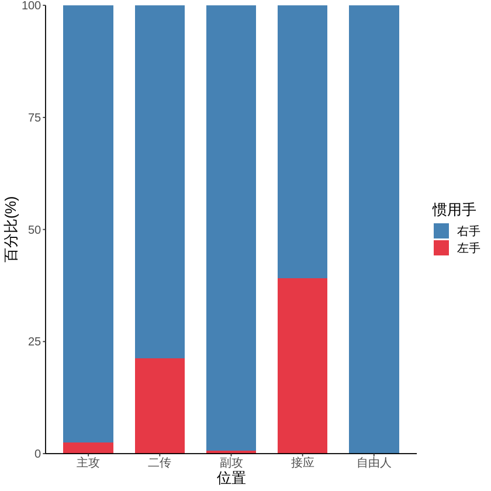

```r
#读取数据
pos_hand<- readxl::read_xlsx("main_data.xlsx",sheet=4)
#设置变量类型
pos_hand$位置<-as.factor(pos_hand$位置)
pos_hand$惯用手<-as.factor(pos_hand$惯用手)
pos_hand$百分比<-as.numeric(pos_hand$百分比)
#绘制百分比堆叠柱状图，设置柱子颜色和宽度
p5<-ggplot(pos_hand, aes(x=位置, y=百分比, fill=惯用手)) +
  geom_bar(stat="identity",width=0.7)+
  scale_fill_manual(values=c("steelblue","#e63946"))+
  theme_classic()+
  theme(plot.background = element_rect(fill = "white"))+
  scale_y_continuous(expand = c(0, 0))+
  theme(text=element_text(size=15))+
  labs(y="百分比(%)")
p5
```

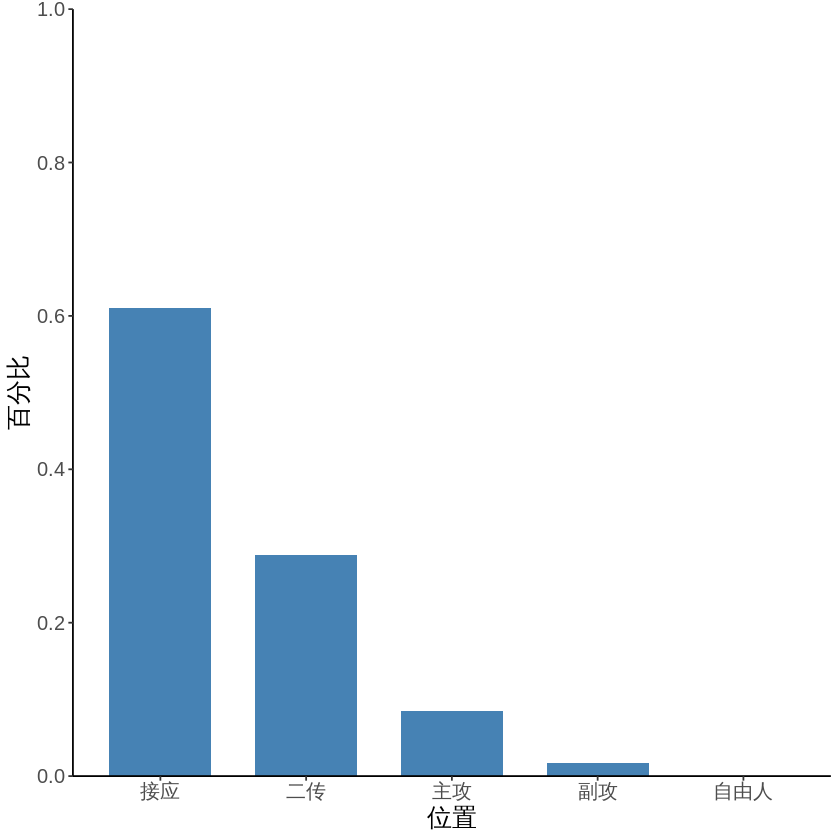

```r
#读取数据
pos_left<- readxl::read_xlsx("main_data.xlsx",sheet=5)
#设置变量类型
pos_left$位置<-as.factor(pos_left$位置)
#绘制直方图
p6<-ggplot(pos_left, aes(x=reorder(位置,-百分比), y=百分比)) +
  geom_bar(stat="identity",width=0.7,fill="steelblue")+
  theme_classic()+
  theme(plot.background = element_rect(fill = "white"))+
  #设置y轴单位长度
  scale_y_continuous(expand = c(0, 0),breaks = seq(0, 1, 0.2),limits = c(0,1))+
  theme(text=element_text(size=15))+
  labs(x="位置")
p6
```

#### 3.2.3 扣球高度和拦网高度

扣球高度和拦网高度是攻手在进攻和防守方面能力的重要指标，通常情况下身高和这两项高度成正比，但身高之余，球员的弹跳能力同样会影响高度。采用散点图分析身高和扣球（拦网）高度的相关性（如图7、图8所示），并用线性拟合进行观测，扣球高度选取主攻、副攻和接应的数据，拦网高度选取除了自由人的球员数据。

```
Warning message:
“Removed 9 rows containing non-finite values (stat_smooth).”
Warning message:
“Removed 9 rows containing missing values (geom_point).”
```

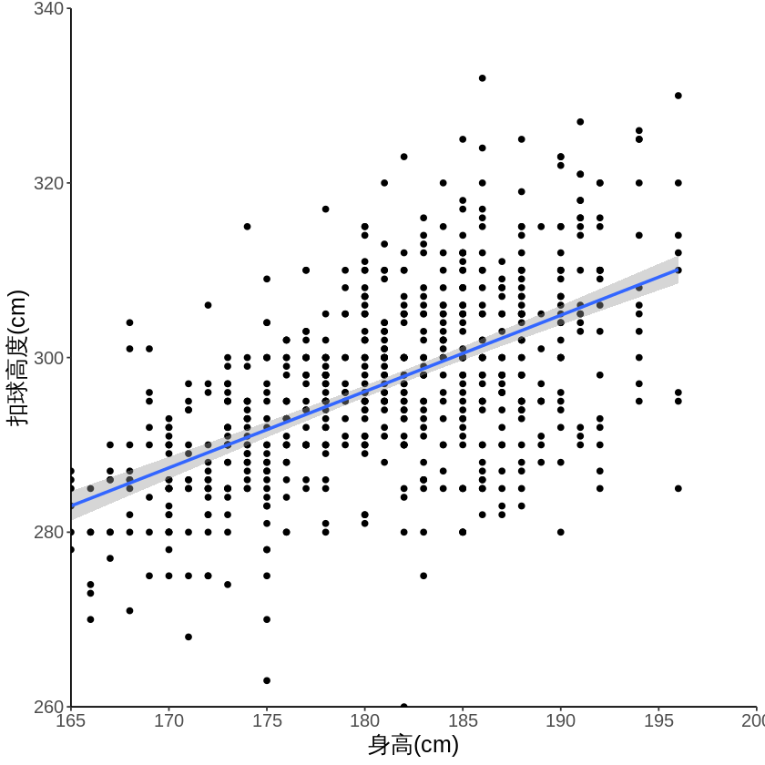

```r
#读取数据
spike_height<- readxl::read_xlsx("main_data.xlsx",sheet=6)
#设置变量类型
spike_height$身高<-as.numeric(spike_height$身高)
spike_height$扣球高度<-as.numeric(spike_height$扣球高度)
#绘制散点图和线性拟合线
p7<-ggplot(spike_height, aes(x=身高, y=扣球高度)) +
  geom_point() +
  #线性拟合线
  geom_smooth(method="lm")+
  theme_classic()+
  theme(plot.background = element_rect(fill = "white"))+
  #设置x轴与y轴范围与单位
  scale_y_continuous(expand = c(0, 0),breaks = seq(260, 340, 20),limits = c(260,340))+
  scale_x_continuous(expand = c(0, 0),breaks = seq(165, 200, 5),limits = c(165,200))+
  theme(text=element_text(size=15))+
  labs(x="身高(cm)",y="扣球高度(cm)")
p7
```

```
Warning message:
“Removed 6 rows containing non-finite values (stat_smooth).”
Warning message:
“Removed 6 rows containing missing values (geom_point).”
```

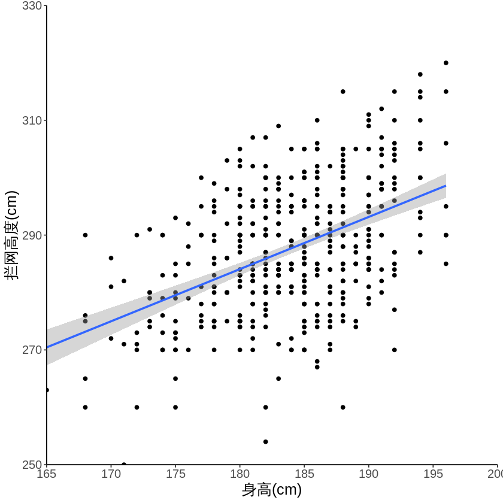

```r
#读取数据
block_height<- readxl::read_xlsx("main_data.xlsx",sheet=7)
#设置变量类型
block_height$身高<-as.numeric(block_height$身高)
block_height$拦网高度<-as.numeric(block_height$拦网高度)
#绘制散点图和线性拟合线
p8<-ggplot(block_height, aes(x=身高, y=拦网高度)) +
  geom_point() +
  #添加线性拟合线
  geom_smooth(method="lm")+
  theme_classic()+
  scale_y_continuous(expand = c(0, 0),breaks = seq(250, 330, 20),limits = c(250,330))+
  scale_x_continuous(expand = c(0, 0),breaks = seq(165, 200, 5),limits = c(165,200))+
  theme(plot.background = element_rect(fill = "white"))+
  theme(text=element_text(size=15))+
  labs(x="身高(cm)",y="拦网高度(cm)")
p8
```

虽然相同身高下的高度数据有30cm左右的波动，但均基本呈现出身高与扣球高度、拦网高度正相关的规律。在拟合曲线以上的数据点代表该球员的扣球高度和拦网高度超出平均水平，而作为教练可以重点关注拟合曲线上方的极端异常值，即表明该球员拥有与自己身高不符的超高拦网或扣球高度，可以进行重点跟踪或培养。

### 3.3 球队建设及人才培养

在保证球员拥有较强的个人基本身体素质和能力之余，整个球队年龄梯度的合理性是保持球队长期竞争力的关键。由于身体机能下滑或伤病，排球运动员的竞技水平巅峰期并不长，因此球队需要时刻拥有一定数量的比赛经验丰富的老将和潜力无限身体素质出众的新人才能抵御球员意外伤病或状态快速下滑的冲击，维持整体的高竞技水平和国际统治力。

#### 3.3.1 球员年龄、比赛经验与竞技水平

选取2023年世界排名在500名以内的球员，使用箱线图考察其年龄与比赛场数的关系，箱线图的宽度表示样本量。比赛场数越多说明球员的比赛时长越长，比赛经验越丰富，更适合在国际大赛中担任稳定球队的核心和主心骨角色。根据图9可知，22岁-25岁年龄段的箱线图最宽，其他年龄段的宽度以这个年龄段逐渐变窄，说明22-25岁期间排球运动员普遍有较好的竞技状态，并且可以进入高水平联赛参加比赛，而随着年龄增长，现役球员数量逐渐减少，说明伤病、竞技状态下滑、其他人生规划等原因都会导致球员退役或淡出高水平竞技，38岁以上仍然在打高水平比赛的球员已经非常少了。 考察不同年龄段球员的比赛场数，发现比赛场数与年龄呈正相关，其中18-21岁存在较多异常值，主要是向上偏离平均值，可能得益于现在儿童排球训练和青少年排球联赛的普及。由于这类球员接触竞技性比赛较早，比赛心态较好，实战经验较多，可以重点关注。

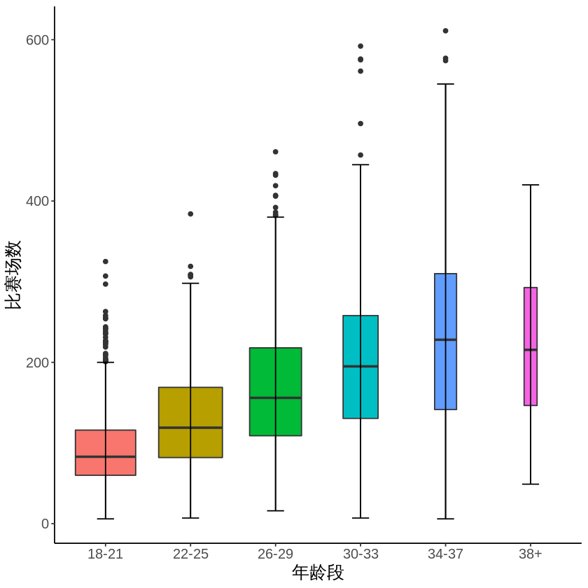

```r
#读取数据
agerange_exp<- readxl::read_xlsx("main_data.xlsx",sheet=8)
#设置变量类型
agerange_exp$年龄段<-as.factor(agerange_exp$年龄段)
agerange_exp$比赛场数<-as.numeric(agerange_exp$比赛场数)
#绘制含误差线的直方图
p10<-ggplot(agerange_exp, aes(x=年龄段, y=比赛场数)) +
  geom_boxplot(aes(fill = 年龄段),varwidth = TRUE,show.legend = F)+
  stat_boxplot(geom = "errorbar",
               lwd=0.5,
               width=0.2)+
  theme_classic()+
  theme(plot.background = element_rect(fill = "white"))+
  theme(text=element_text(size=15))+
  labs(x="年龄段",y="比赛场数")
p10
```

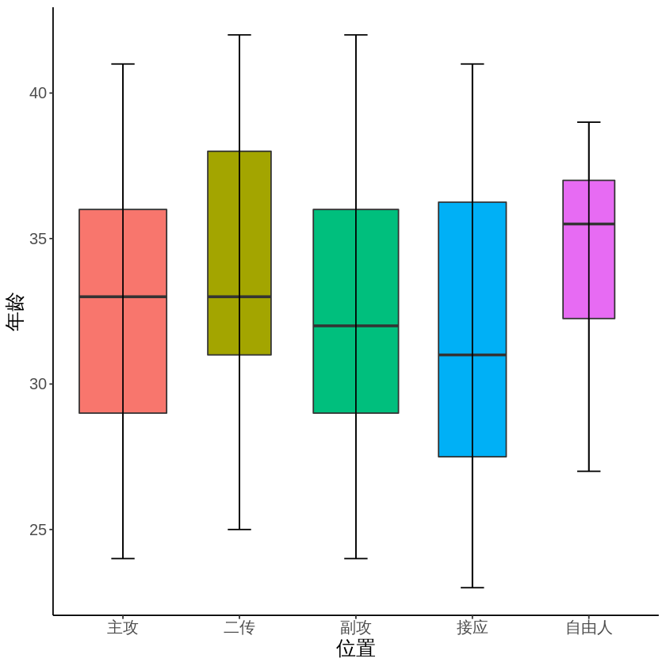

```r
#读取数据
age_pos<- readxl::read_xlsx("main_data.xlsx",sheet=9)
#设置变量类型
age_pos$位置<-as.factor(age_pos$位置)
age_pos$年龄<-as.numeric(age_pos$年龄)
#绘制箱线图
p11<-ggplot(age_pos, aes(x=位置, y=年龄)) +
  geom_boxplot(aes(fill = 位置),varwidth = TRUE,show.legend = F)+
  stat_boxplot(geom = "errorbar",
               lwd=0.5,
               width=0.2)+
  theme_classic()+
  theme(plot.background = element_rect(fill = "white"))+
  theme(text=element_text(size=15))+
  labs(x="位置",y="年龄")
p11
```

考察Top500球员中137位现役球员的年龄，发现自由人的巅峰年龄最大，可能原因是自由人对弹跳能力、肩背力量等随着年龄增加而损耗快的能力的要求不如其他位置，另一个原因可能是自由人对于比赛经验的要求更高，因此年龄越大，比赛技能和心态越强。接应在所有位置中巅峰年龄最低，可能说明该位置球员进步曲线最快，训练的边际效益最高。

#### 3.3.2 中国各年龄的人才储备与国家间对比

国家队需要有一个较为合理的年龄梯度，保证新人的人才储备。选择同为亚洲国家和世界女排强队的日本队进行对比，选取数据集中所有收录的中国和日本球员的数据，忽略球员世界排名、联赛比赛次数等限制，以最大程度囊括两国现有的职业排球运动员人才。以2岁为一分段，使用金字塔图描述两国人才储备情况（如图11所示）。作为需要从小长时间训练积累的运动，排球的球员年龄金字塔图并未呈现逐渐收窄的趋势，可能原因是数据库对低级别联赛的统计有所欠缺，或部分球员选择等到竞技水平较高时再参加职业比赛。钟型分布的球员年龄结构属于合理范畴。

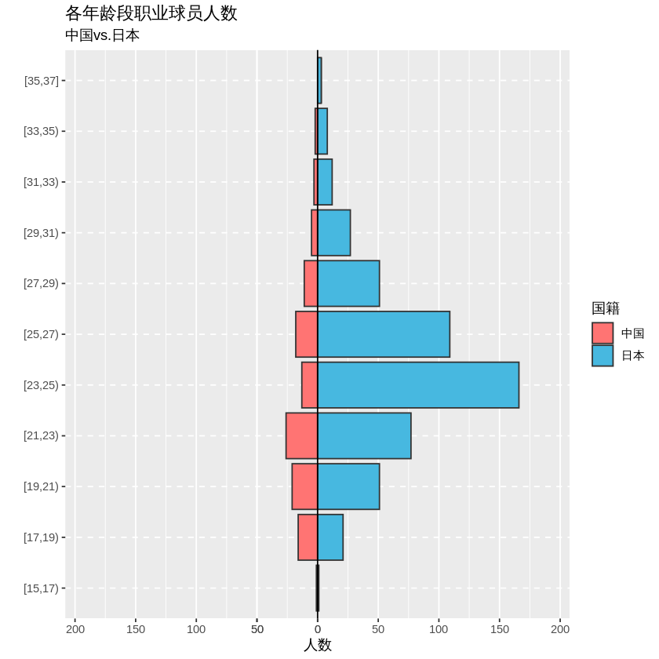

```r
#读取数据
age_coun<- readxl::read_xlsx("main_data.xlsx",sheet=10)
#将数据格式改为表格，设置变量类型
age_coun<-as.data.table(age_coun)
age_coun$国籍<-as.factor(age_coun$国籍)
age_coun$年龄<-as.numeric(age_coun$年龄)
#设置金字塔图纵轴刻度（球员年龄）
age_coun[,age_cut:=cut(年龄,breaks = c(15,17,19,21,23,25,27,29,31,33,35,37),
                     right = F,include.lowest = T)]
#绘制金字塔图，以每个年龄段内的人数为x轴，以国家为分组依据
p12<-age_pyramid(data = age_coun,
                      age_group = "age_cut",
                      split_by = "国籍",show_midpoint=F)+
  labs(title ="各年龄段职业球员人数",
       subtitle="中国vs.日本",
       x=" ",
       y="人数")+
scale_fill_manual(values=c("#ff7473","#47b8e0"))
p12
```

根据图11可知，中国总人口是日本的几倍，但各年龄分段下的排球运动员数量均小于日本，且值得注意的是17-19岁的职业球员人数差距不大，但是在19-21岁的年龄区间内开始出现明显区别，说明日本排球职业化的比例显著高于中国，间接表现出排球在中国的群众基础仍然较薄弱，且排球联赛等与排球密切相关的职业场景发展大不如日本，很多本来想走职业道路的青年球员因为各种原因不再参与职业排球。此外还可能由于相较日本球员，中国球员普遍更早开始职业排球，由于身体素质更好、技术成熟更早，能够更早参加职业比赛，而日本球员需要等到23岁后才能出现技术的大爆发。更早职业化的优点是比赛经验相比其他同龄国际球员更加丰富，但出现伤病的时间点也可能更早，职业生涯可能更短。这一点需要国内排球教练着重关注。 相比中国每个年龄段的球员人数基本类似，日本的球员梯度明显更加有优势。23-27岁是球员身体素质的巅峰期，该年龄段的球员数量占比最大，大基数的基础上几乎能够确保有十几位球员能够迅速成长，同时积累比赛经验，成为未来几年球队的中流砥柱。而中国的球员梯度结构就容易面临球员断层的风险。

#### 3.3.3 各国球员留洋情况

留洋是指球员加盟本国以外的排球俱乐部参加外国排球联赛，对球员个人能力的提升基本都有非常大的帮助。留洋比赛可以帮助球员接触不同国家的球员，了解自己未来国家队比赛中的对手和当下排坛最顶尖的球员，适应不同的比赛风格和比赛节奏，提高自己的适应性和调整性以便在国家队比赛遭遇非常规对手或局面时仍然能够发挥自己应有的水平，带球队取得胜利。考察世界排名靠前的国家的本土球员人数、联赛球员人数和本土球员的留洋情况（如图12），发现较多世界强队的国内联赛的规模都相当庞大，如美国、土耳其、波兰等，表明这些国家的民众和官方对排球运动的喜爱和对发展及成绩的重视，一定程度上解释了这些强队的高竞争力。相比之下中国球员总数更少，排球联赛的规模更小，与中国的总人口不成比例，表明排球的群众基础仍然较为薄弱，排球职业联赛的商业化也尚未完善，因此无法吸引很多其他国家的球员“留洋”来到中国排球联赛打球。

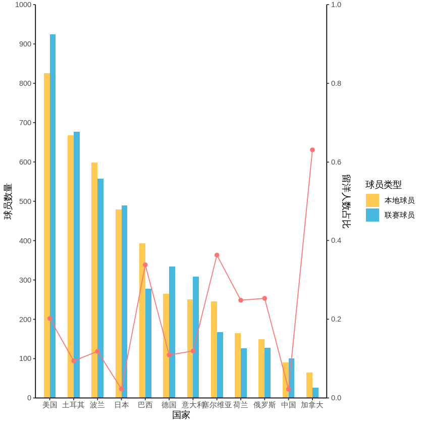

```r
#读取数据。
#该数据为各国本土球员（国籍为该国）与联赛球员（在该国联赛打球）人数。
league_oversea<-readxl::read_xlsx("main_data.xlsx",sheet=11)
#该数据为各国留洋比例，为在非本国排球俱乐部效力的球员数量除以该国总球员数
oversea<-readxl::read_xlsx("main_data.xlsx",sheet=12)
#绘制双轴分组柱状图-折线图
#首先绘制分组柱状图，分组类别为本土球员与联赛球员。横轴为国家，从左到右以本土球员数量从多到少进行排序；左侧纵轴为球员数量。
p13<-ggplot(league_oversea)+
geom_col(aes(reorder(国籍国家,-数量),数量,fill=球员类型),position = 'dodge',width = 0.5)+
  scale_fill_manual(values = c('#ffc952','#47b8e0'))+
  #定义x轴名称和左侧y轴名称
  labs(x='国家',y='球员数量')+
  theme_test(base_size = 15)+
  theme_classic() +
  theme(plot.background = element_rect(fill = "white"))+
  #定义主要纵轴（左侧y轴）的区间与单位，并增加一条右侧y轴，定义名称并确定该轴的区间与单位
  scale_y_continuous(limits = c(0,1000),
                     breaks = seq(0,1000,100),
                     expand = c(0,0),
                     sec.axis = sec_axis(~./1000,
                                         name = '留洋人数占比',
                                         breaks = seq(0,1,0.2)))+
  #添加各国球员留洋比例数据点。由于geom_point默认以主要（左侧）纵轴为基准绘图，故将留洋人数占比手动乘以1000与左侧y轴区间匹配，同时与右侧y轴的数值相对应
  geom_point(data=oversea,aes(国籍国家,留洋人数占比*1000,group=1),size=2,color="#ff7473")+
  #为折线图添加连接线，突出折线上的点
  geom_line(data=oversea,aes(国籍国家,留洋人数占比*1000,group=1),color="#ff7473")
p13
```

进一步考察各个国家球员的留洋比例，发现本土联赛发展较好的欧美国家的球员普遍留洋比例较低，基本不超过20%，球员倾向于在本国俱乐部效力，典型国家为美国、波兰、意大利；巴西作为南美国家也拥有较大规模的本土联赛，但或许由于排球运动战术和技术普遍欧美化的趋势，很多高水平球员为了提升自己会选择留洋打球；而加拿大、塞尔维亚、荷兰等本土联赛发展相对不好的国家的球员则有较高的留洋率，球员寻求在更高更优秀的平台与更优秀的队友合作，提升自己的竞技水平。相比之下，中国的留洋率非常低，几乎为0，但国内联赛发展也较为薄弱，在留洋方面与其他世界强队有较大差距，可能原因是球员主观意愿或留洋限制，可以在未来的留洋策略上进行优化调整。

## 4. 结论

本报告通过一系列的数据可视化分析，揭示了中国女排在国际竞争中的当前位置和面临的挑战，并提供了关于人才选拔和队伍建设的具体策略建议。为提高未来竞争力，建议加强对球员个人能力的培养，优化选拔机制，并在国际比赛中积累更多经验。这些措施将为中国女排在未来国际大赛中取得成功奠定坚实的基础。本报告得出了以下几点重要结论：

**球员个人能力**

尽管中国拥有顶尖球员朱婷，但在Top100球员分布中，中国的顶尖球员数量远不及其他主要竞争国家。中国在培养更多顶尖球员方面存在缺口。

**年龄与比赛经验**

高水平职业球员中在22至25岁区间内的球员数量最多，说明这一年龄段的球员通常处于竞技水平的高峰。然而，随着年龄的增长，活跃在高水平竞技的球员数量逐渐减少，这强调了维持年轻球员梯队和高水平老将的平衡的重要性。

**球员留洋策略**

可视化分析表明，中国球员的留洋比例非常低；相比其他排球强国，中国的排球联赛规模较小，国际化程度较低，国内球员的国际经验也较少。数据说明强队通常拥有庞大的国内联赛和高水平的国际参与，强调了留洋对于提升国家队水平的重要性。